# Analysis of Transimission Type and MPG: An Exploratory Study

#### MPG, Cylinder and Transmission

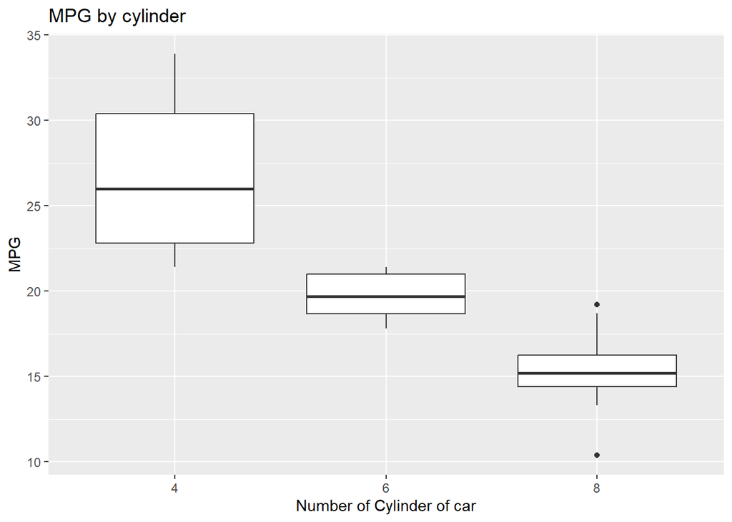

```r
ggplot(mtcars)+
 geom_boxplot(aes(x=factor(cyl), y=mpg)) +
 labs(title = "MPG by cylinder", x = "Number of Cylinder of car", y = "MPG")
```

Here we see that cars with 4 cylinders have relatively highest median MPG whereas cars with 8 cylinders have the lowest median MPG and Cars with 6 cylinders have in-between median MPG.

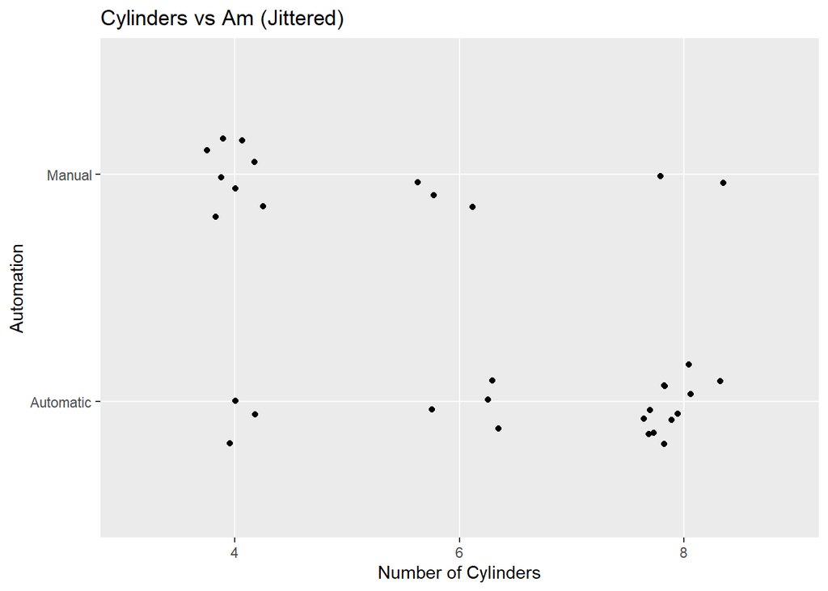

```r
ggplot(mtcars, aes(x = factor(cyl), y = factor(am))) +
  geom_jitter(width = 0.2, height = 0.2) +
  labs(title = "Cylinders vs Am (Jittered)",
       x = "Number of Cylinders",
       y = "Automation") +
  scale_y_discrete(labels = c("0" = "Automatic", "1" = "Manual"))
```

Here we see that most of the manual cars have 4 cylinders and most of the Automatic cars have 8 Cylinders. Supporting the previous analysis again as most of the manual cars have higher MPGs than that of Automatic cars.

#### MPG and Engine type

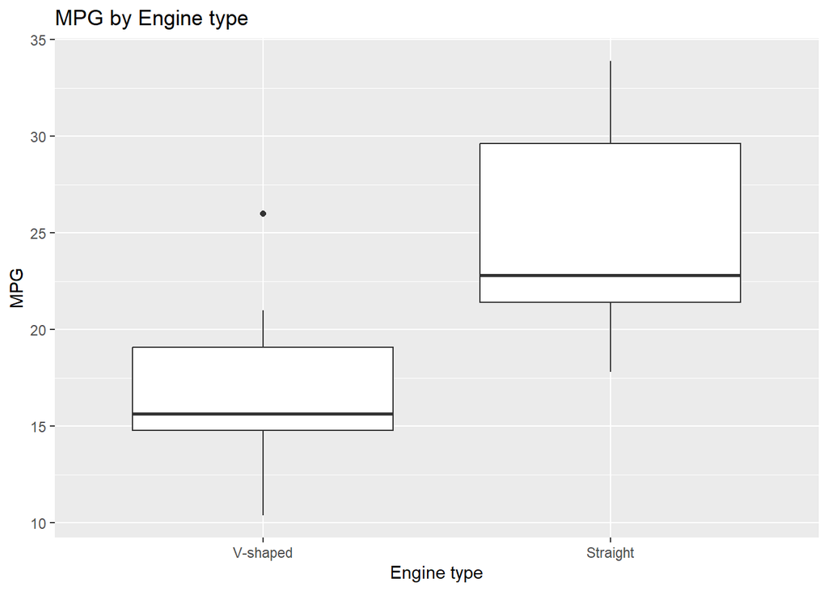

```r
ggplot(mtcars)+
 geom_boxplot(aes(x=factor(vs), y=mpg)) +
 labs(title = "MPG by Engine type", x = "Engine type", y = "MPG")+
scale_x_discrete(labels = c("0" = "V-shaped", "1" = "Straight"))
```

Here we see that cars with Straight engine have relatively Higher median MPG whereas cars with V-shaped have the Lower median MPG in the mtcars data.

## Correlation analysis

### MPG and Weight

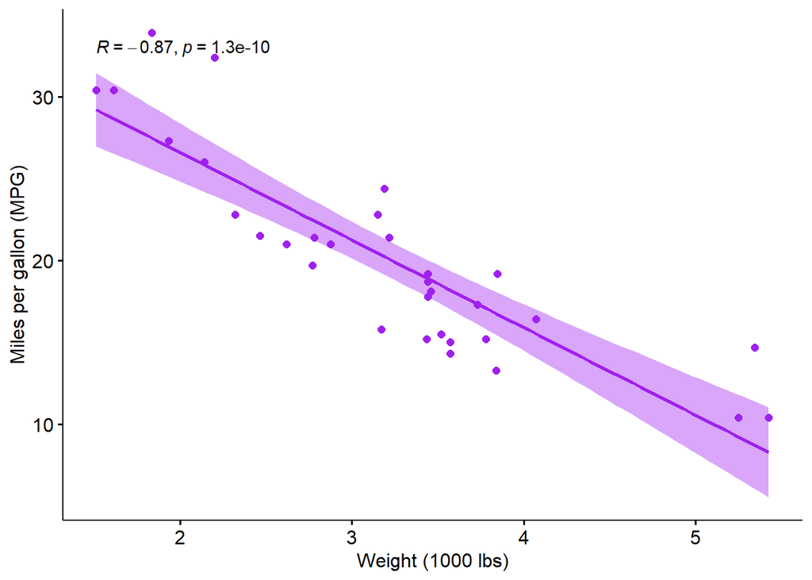

```r
ggscatter(mtcars, x = "wt", y = "mpg",
 add = "reg.line", conf.int = TRUE,
 cor.coef = TRUE, cor.method = "pearson",
  xlab = "Weight (1000 lbs)", ylab = "Miles per gallon (MPG)", color = "purple")
```

Here we see that MPG and weight of cars are highly negetively correlated as the R value is -0.87.

### MPG and horsepower

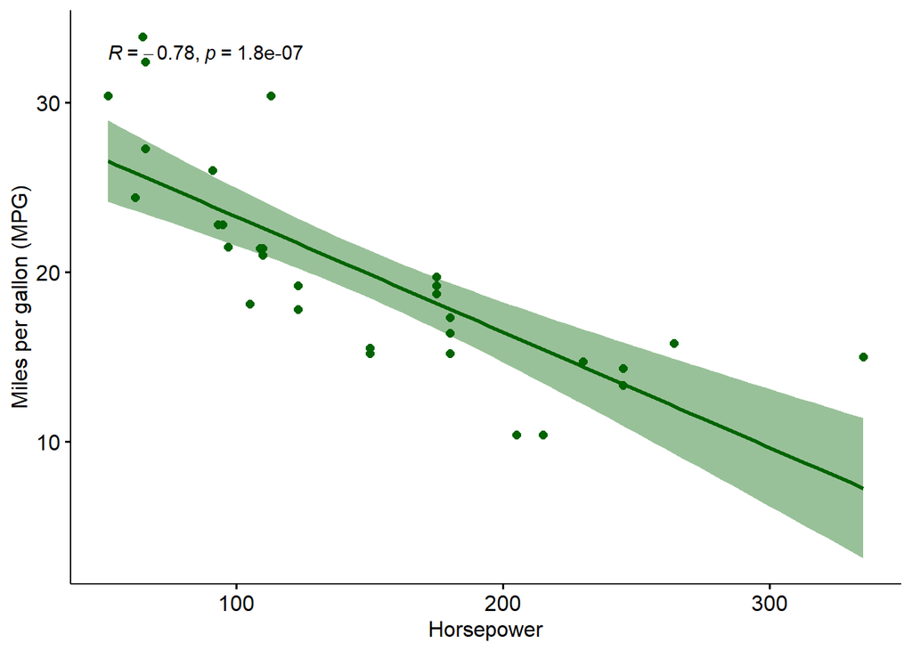

```r
ggscatter(mtcars, x = "hp", y = "mpg",
 add = "reg.line", conf.int = TRUE,
 cor.coef = TRUE, cor.method = "pearson",
  xlab = "Horsepower", ylab = "Miles per gallon (MPG)", color = "darkgreen")
```

Here we see that MPG and Horsepower of cars are highly negetively correlated as the R value is -0.78.

### MPG and displacement

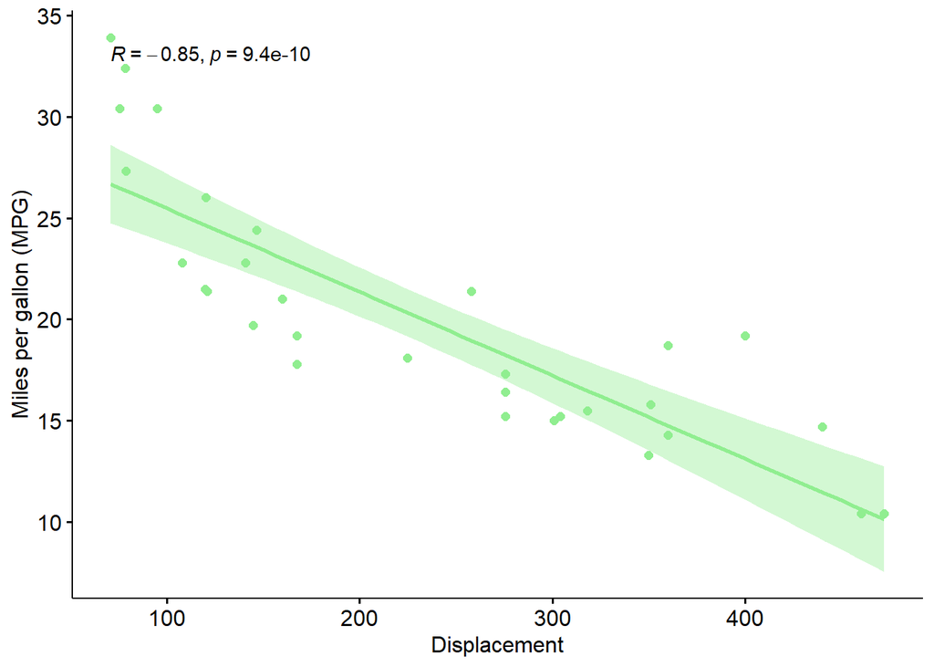

```r
ggscatter(mtcars, x = "disp", y = "mpg",
 add = "reg.line", conf.int = TRUE,
 cor.coef = TRUE, cor.method = "pearson",
  xlab = "Displacement", ylab = "Miles per gallon (MPG)", color = "lightgreen")
```

Here we see that MPG and displacement of cars are highly negetively correlated as the R value is -0.85.

### Weight and horsepower

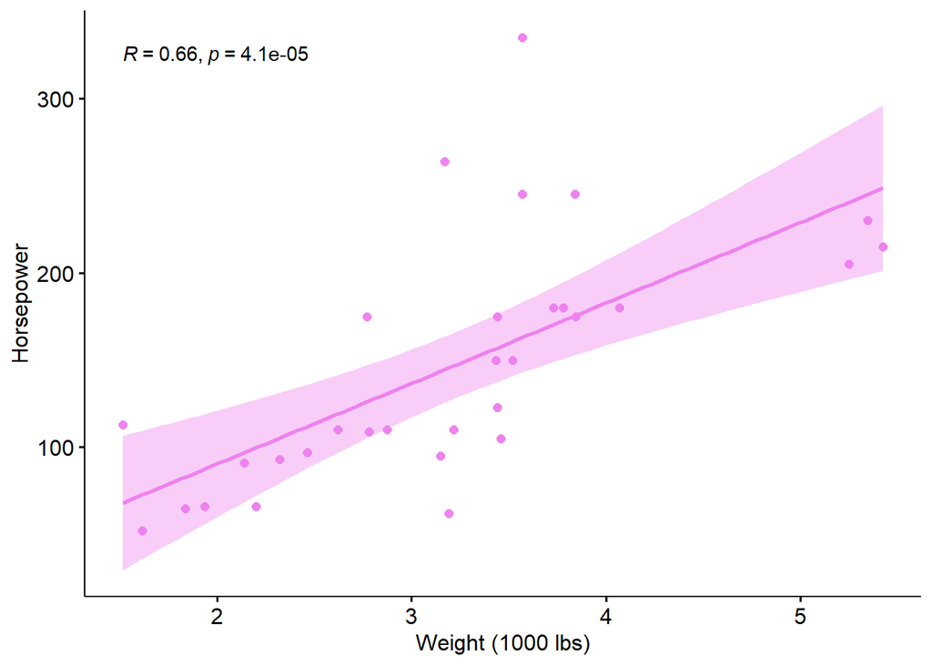

```r
ggscatter(mtcars, x = "wt", y = "hp",
 add = "reg.line", conf.int = TRUE,
 cor.coef = TRUE, cor.method = "pearson",
  xlab = "Weight (1000 lbs)", ylab = "Horsepower", color = "violet")
```

Here we see that weight and Horsepower of cars are moderately correlated as the R value is 0.66. **This indicates that if we consider both weight and the horsepower as the predictor variables, likely we can eliminate the possibilty of multi-collinearity issue in our model**

### Displacement and weight

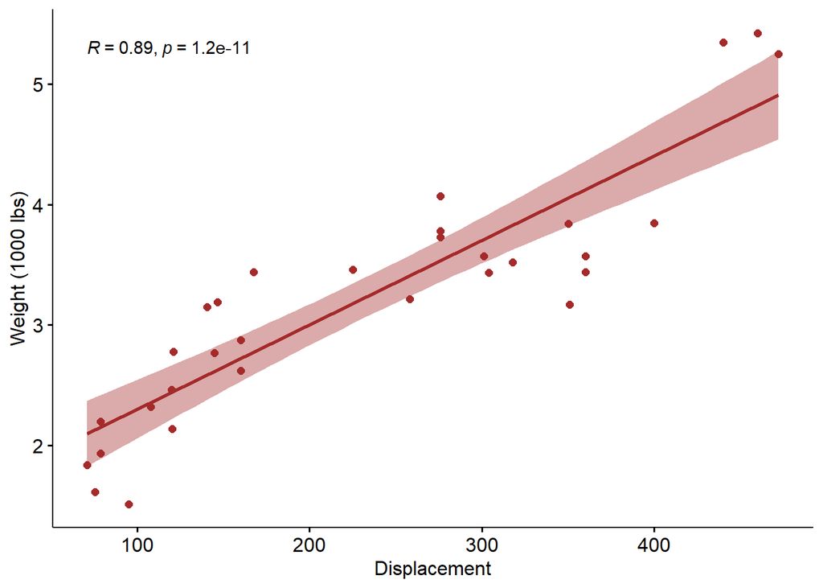

```r
ggscatter(mtcars, x = "disp", y = "wt",
 add = "reg.line", conf.int = TRUE,
 cor.coef = TRUE, cor.method = "pearson",
  xlab = "Displacement", ylab = "Weight (1000 lbs)", color = "brown")
```

## Group comparision

We’ll perform the t.test or two-sample t-test on the mpg of mtcars data, comparing the two groups in the Transmission variable (Automatic v/s Manual). We’ll be testing if the estimated population means of MPGs are different between the two Transmissions type.

```r
t.test(mpg ~ am, data = mtcars)
```

```
##
##  Welch Two Sample t-test
##
## data:  mpg by am
## t = -3.7671, df = 18.332, p-value = 0.001374
## alternative hypothesis: true difference in means between group 0 and group 1 is not equal to 0
## 95 percent confidence interval:
##  -11.280194  -3.209684
## sample estimates:
## mean in group 0 mean in group 1
##        17.14737        24.39231
```

The null hyposthesis is that there is no difference between the means of the two groups.  
The alternative hypothesis is that there is a difference in the means between the two groups.

The P-value in this test is 0.001374 which is smaller than 0.05 (at 5% significance level), which indicates that *the null hypothesis is likely false*. This means that we reject the null hypothesis and the data suggests that the mean MPGs of two groups (Automatic and Manual) might be different.

The confidence interval at 95% level indicates that the differences in means of two groups (Population mean of Automatic transmission’s MPG - population mean of Manual transmission’s MPG)is in between:  
-11.280194 to -3.209684

*Since the interval doesn’t contain 0, this means that the data does support the possibility of having difference in mean MPGs of the types of transmission (which aligns with the p-value above).*

## Model Selection and Fitting

We have selected 5 possible independent predictor variables to put in our model for MPG as the response variable based on these reasons:  
- am (Transmission): The high probability that the population mean MPGs of two groups are different.  
- wt (Weight): The weight is highly correlated with our response variable(mpg).  
- hp (Horsepower): The horsepower is highly correlated with our response variable(mpg).  
- vs (Engine type): Different engine type have different MPGs considering most proportion of the samples.  
- cyl (Cylinders) : Number of cylinder affects the MPGs of the car samples and have some pattern with transmission type.

**We won’t consider displacement to avoid any multi-collinarity issues in our model.**

5 models will be constructed each time feeding one potential predictor variable. Each model will then be tested using Variance Inflation Factor, AIC, BIC, ANOVA and adjusted R-squared to find the best suitable model.

```r
fit1 <- lm(mpg~am, data = mtcars)
fit2 <- lm(mpg~am + hp, data = mtcars)
fit3 <- lm(mpg~am + hp + wt, data = mtcars)
fit4 <- lm(mpg~am + hp + wt + vs, data = mtcars)
fit5 <- lm(mpg~am + hp + wt + vs + cyl, data = mtcars)
```

### Variance Influence Factor(VIF) / Multi-collinarity Test

```r
vif(fit5)
```

```
##       am       hp       wt       vs      cyl
## 3.258633 4.357558 4.032428 4.021651 9.677768
```

We see that the VIF of cyl in very large (9.67). We might consider not feeding our model with cylinder variable. We might consider eliminating the fit5 model.

```r
vif(fit4)
```

```
##       am       hp       wt       vs
## 2.346839 2.788404 3.991516 2.216443
```

```r
vif(fit3)
```

```
##       am       hp       wt
## 2.271082 2.088124 3.774838
```

```r
vif(fit2)
```

```
##       am       hp
## 1.062867 1.062867
```

We see that the VIF of all other models are less than 5, indicating that other models has acceptable multi-collinearity.

### ANOVA test

```r
anova(fit1,fit2,fit3,fit4,fit5)
```

```
## Analysis of Variance Table
##
## Model 1: mpg ~ am
## Model 2: mpg ~ am + hp
## Model 3: mpg ~ am + hp + wt
## Model 4: mpg ~ am + hp + wt + vs
## Model 5: mpg ~ am + hp + wt + vs + cyl
##   Res.Df    RSS Df Sum of Sq       F    Pr(>F)
## 1     30 720.90
## 2     29 245.44  1    475.46 73.8843 4.484e-09 ***
## 3     28 180.29  1     65.15 10.1238  0.003769 **
## 4     27 168.96  1     11.33  1.7603  0.196128
## 5     26 167.31  1      1.65  0.2563  0.616941
## ---
## Signif. codes:  0 '***' 0.001 '**' 0.01 '*' 0.05 '.' 0.1 ' ' 1
```

### Adjusted R-squared comparision

```r
summary(fit1)$adj.r.squared
```

```
## [1] 0.3384589
```

```r
summary(fit2)$adj.r.squared
```

```
## [1] 0.7670025
```

```r
summary(fit3)$adj.r.squared
```

```
## [1] 0.8227357
```

```r
summary(fit4)$adj.r.squared
```

```
## [1] 0.8277202
```

```r
summary(fit5)$adj.r.squared
```

```
## [1] 0.8228405
```

We see that the Adjusted r square is higher, around 0.82 for fit3, fit4 and fit5.

### AIC and BIC Test

```r
AIC(fit1,fit2,fit3,fit4,fit5)
```

```
##      df      AIC
## fit1  3 196.4844
## fit2  4 164.0061
## fit3  5 156.1348
## fit4  6 156.0584
## fit5  7 157.7445
```

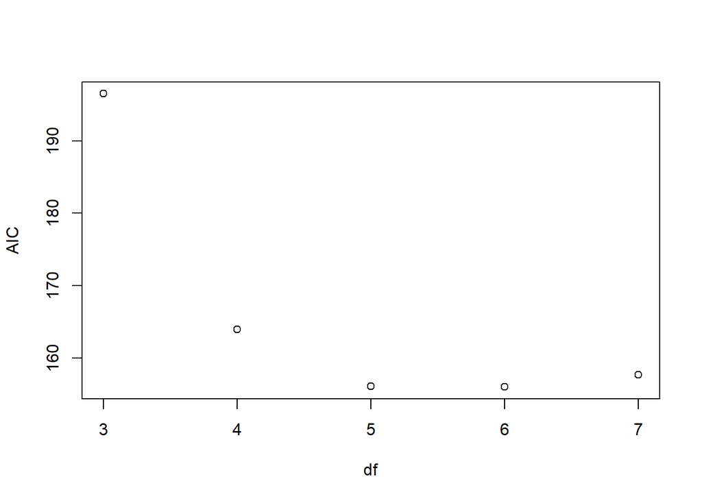

```r
plot(AIC(fit1,fit2,fit3,fit4,fit5))
```

```r
BIC(fit1,fit2,fit3,fit4,fit5)
```

```
##      df      BIC
## fit1  3 200.8816
## fit2  4 169.8690
## fit3  5 163.4635
## fit4  6 164.8528
## fit5  7 168.0046
```

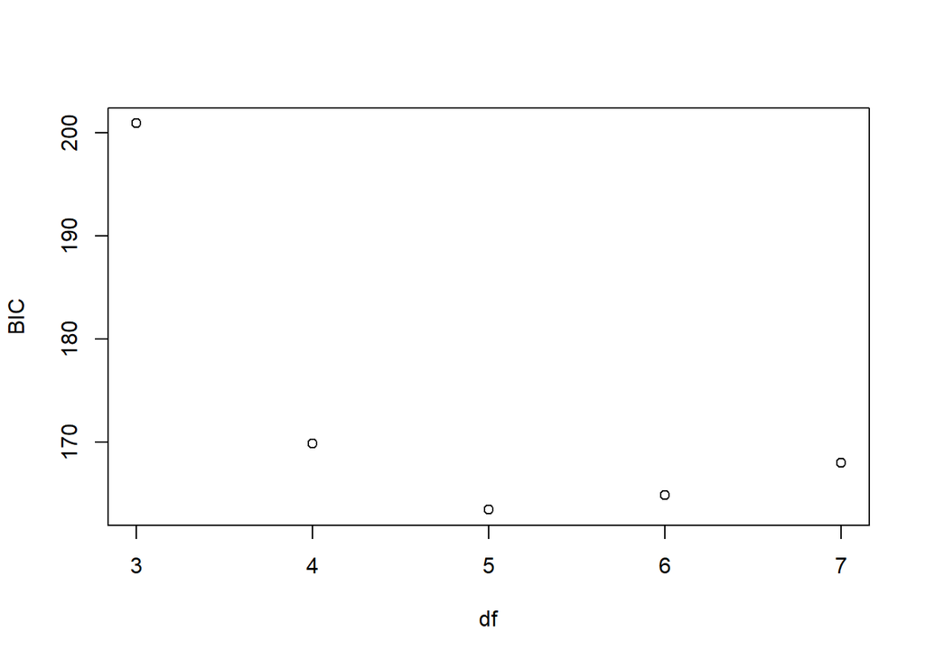

```r
plot(BIC(fit1,fit2,fit3,fit4,fit5))
```

We see the BIC values is significantly lowest on fit3 then starts to rise again from fit4 to fit5. Suggesting that best model is either fit3.

### Bonus (checking other variales concluding overfitting):

If we fit all other varaiables in the data set one by one in each method, it results to overfitting, suggesting that fit3 is the best fit for the model.

```r
fit6 <- lm(mpg~am + hp + wt + gear, data = mtcars)
fit7 <- lm(mpg~am + hp + wt + gear + carb, data = mtcars)
fit8 <- lm(mpg~am + hp + wt +gear + carb+ qsec, data = mtcars)
fit9 <- lm(mpg~am + hp + wt +gear + carb+ qsec + drat, data = mtcars)

AIC(fit1,fit2,fit3,fit6,fit7,fit8,fit9)
```

```
##      df      AIC
## fit1  3 196.4844
## fit2  4 164.0061
## fit3  5 156.1348
## fit6  6 157.9657
## fit7  7 157.8459
## fit8  8 157.0535
## fit9  9 158.5650
```

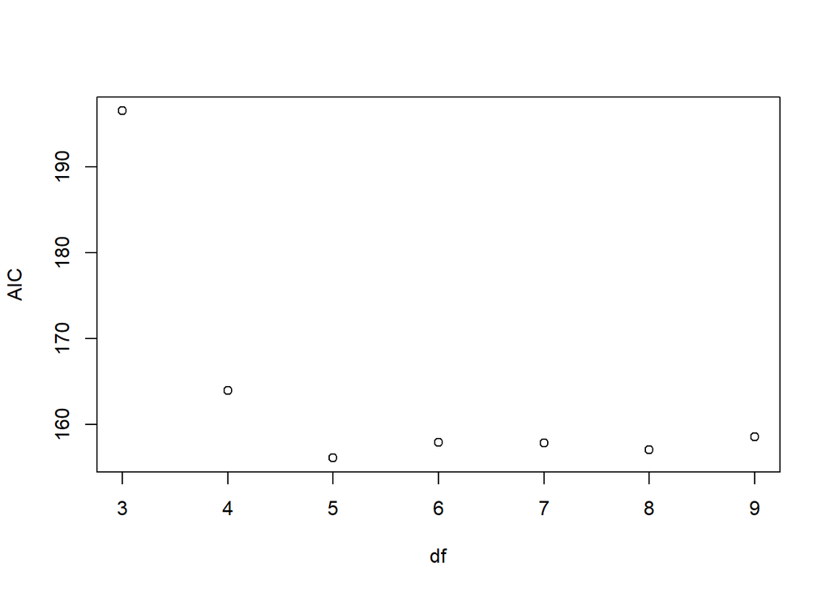

```r
plot(AIC(fit1,fit2,fit3,fit6,fit7,fit8,fit9))
```

```r
BIC(fit1,fit2,fit3,fit6,fit7,fit8,fit9)
```

```
##      df      BIC
## fit1  3 200.8816
## fit2  4 169.8690
## fit3  5 163.4635
## fit6  6 166.7601
## fit7  7 168.1060
## fit8  8 168.7794
## fit9  9 171.7567
```

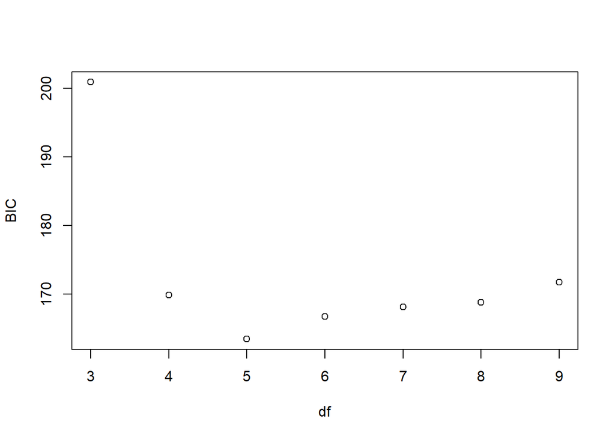

```r
plot(BIC(fit1,fit2,fit3,fit6,fit7,fit8,fit9))
```

## Interpretation of coefficients

```r
summary(fit3)
```

```
##
## Call:
## lm(formula = mpg ~ am + hp + wt, data = mtcars)
##
## Residuals:
##     Min      1Q  Median      3Q     Max
## -3.4221 -1.7924 -0.3788  1.2249  5.5317
##
## Coefficients:
##              Estimate Std. Error t value Pr(>|t|)
## (Intercept) 34.002875   2.642659  12.867 2.82e-13 ***
## am           2.083710   1.376420   1.514 0.141268
## hp          -0.037479   0.009605  -3.902 0.000546 ***
## wt          -2.878575   0.904971  -3.181 0.003574 **
## ---
## Signif. codes:  0 '***' 0.001 '**' 0.01 '*' 0.05 '.' 0.1 ' ' 1
##
## Residual standard error: 2.538 on 28 degrees of freedom
## Multiple R-squared:  0.8399, Adjusted R-squared:  0.8227
## F-statistic: 48.96 on 3 and 28 DF,  p-value: 2.908e-11
```

- Adjusted R squared (0.8227): Around 82.27% of mpg variation can be explained by this model (fit3).
- Residual Standard error (2.5): the observed mpg are 2.5 unit far from predicted model.
- Mean MPG (34): If all predictor variables are 0, mean mpg is 34mpg.
- Slope of transmission (2.08): The effect of changing from automatic to manual transmission on “mpg”, an increase of 2.083710 mpg.
- P value of transmission: As the P value is greater than 0.05, **indicating it’s not statistically significant at the 5% level.**
- Slope of horsepower: A decrease of 0.037479 mpg per unit increase in horsepower, adjusting for transmission.
- P value of horsepower: As the P value is smaller than 0.05, indicating it’s highly statistically significant.
- Slope of weight(1000 lbs): A decrease of 2.878575 mpg per 1000 lbs increase in weight adjusting for transmission.
- P value of weight: As the P value is smaller than 0.05, indicating it’s statistically significant.

```r
confint(fit3)
```

```
##                   2.5 %      97.5 %
## (Intercept) 28.58963286 39.41611738
## am          -0.73575874  4.90317900
## hp          -0.05715454 -0.01780291
## wt          -4.73232353 -1.02482730
```

```r
confint(fit3,level = 0.85)
```

```
##                   7.5 %      92.5 %
## (Intercept) 30.09136037 37.91438987
## am           0.04641094  4.12100932
## hp          -0.05169613 -0.02326132
## wt          -4.21806157 -1.53908925
```

We see that at 85% confidence level, the effect of changing from automatic to manual transmission on “mpg”, an increase of 0.046 to 4.121 mpg. This shows that our model is not accurate enough at predicting the relationship of change in transmission and change in mpg at higher signficance level.

**The P value is not statistically significant, or acquire very strong confidence level. We can enhance inference accuracy with resampling.**

## Boot Strap Analysis

we will define a boot function “boot_fn” which fits the model on resampled data and returns the coefficients. We’ll perform bootstrap analysis with 1000 resamples with replacement and store the result in “bppt_results”. We’ll then observe the output.

```r
boot_fn <- function(data,indices){d <- data[indices, ]
 fitSample<-lm(mpg~am+wt+hp, data = d)
 return(coef(fitSample))}
set.seed(123)
boot_results<- boot(data=mtcars, statistic = boot_fn, R=1000)
boot_results
```

```
##
## ORDINARY NONPARAMETRIC BOOTSTRAP
##
##
## Call:
## boot(data = mtcars, statistic = boot_fn, R = 1000)
##
##
## Bootstrap Statistics :
##        original       bias    std. error
## t1* 34.00287512  0.425564443 3.059919081
## t2*  2.08371013 -0.140591967 1.437006152
## t3* -2.87857541 -0.108576842 1.059896922
## t4* -0.03747873 -0.000494366 0.008584255
```

**Bias:**

For the Intercept (t1*): 0.425564443 / 34.00287512 ≈ 0.0125 (~1.25%) – Acceptable.

**For am (t2*): -0.140591967 / 2.08371013 ≈ -0.0675 (~6.75%) – Slightly higher. **

For wt (t3*): -0.108576842 / -2.87857541 ≈ 0.0377 (~3.77%) – Acceptable.

For hp (t4*): -0.000494366 / -0.03747873 ≈ 0.0132 (~1.32%) – Acceptable.

**Standard Error:**

Relative standard error for each parameter should be considered in the context of the original estimates. Smaller standard errors indicate more precise estimates.

**In general, these biases and standard errors appear reasonable (at 5% significant level), indicating that our original analysis of the model for its coefficients might be true but we still don’t have enough data samples to conclude the accurate results.**

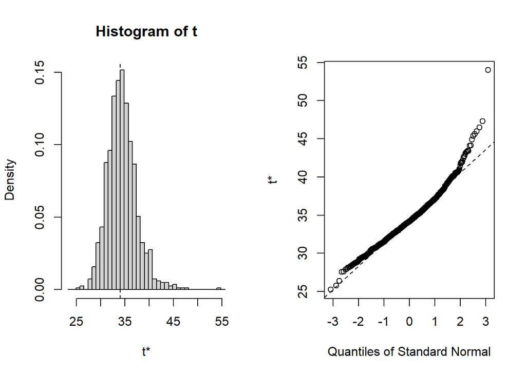

```r
plot(boot_results)
```

In the plot of the boot strap analysis result, we see that almost all of the re-sampled data forms a Gaussian curve indicating normality in the Density of of the data. We can see one outlier in the quntiles of Standard Normal, However if we analyze, the possibility of 1 in 1000 point being an outlier can be considered an error.

## Residual Analysis

### Residual vs Fitted

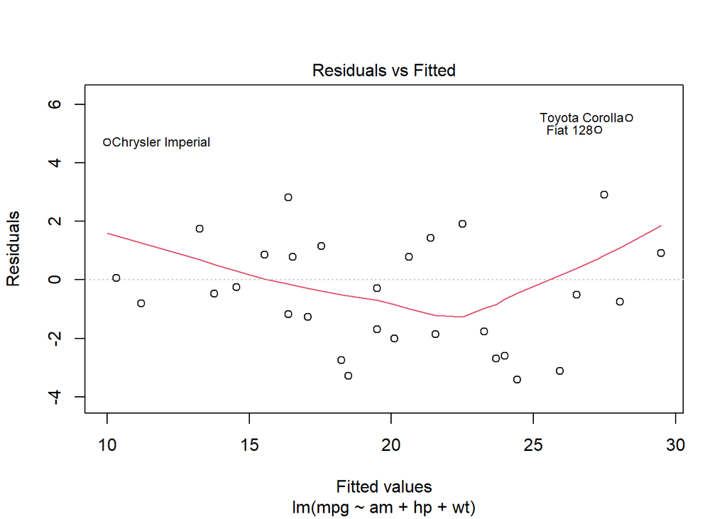

```r
plot(fit3,which = 1)
```

### Normal Q-Q (Quantile-Quantile) Plot

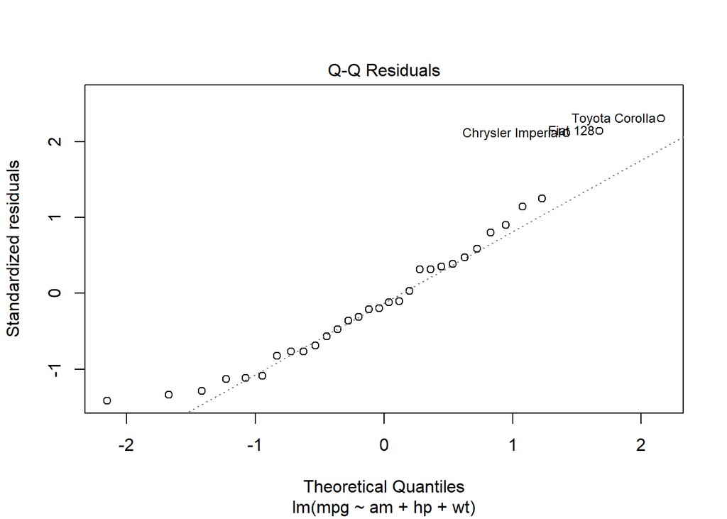

```r
plot(fit3,which = 2)
```

In the plot Normal Q-Q plot, we check if the residual is normally distributed. We see that the points follows the reference line roughly, indicating that the residuals are normally distributed.

We can also check for **Shapiro-Wilk normality test** for the normality test.

```r
shapiro.test(fit3$residuals)
```

```
##
##  Shapiro-Wilk normality test
##
## data:  fit3$residuals
## W = 0.9453, p-value = 0.1059
```

As the W value is close to 1, indicating that the residuals are likely normally distributed.  
Also the P value is 0.1059 which is greater than 0.05, indicating that there is no strong evidence against normality, so the residuals are most likely normally distributed.

### Scale-Location

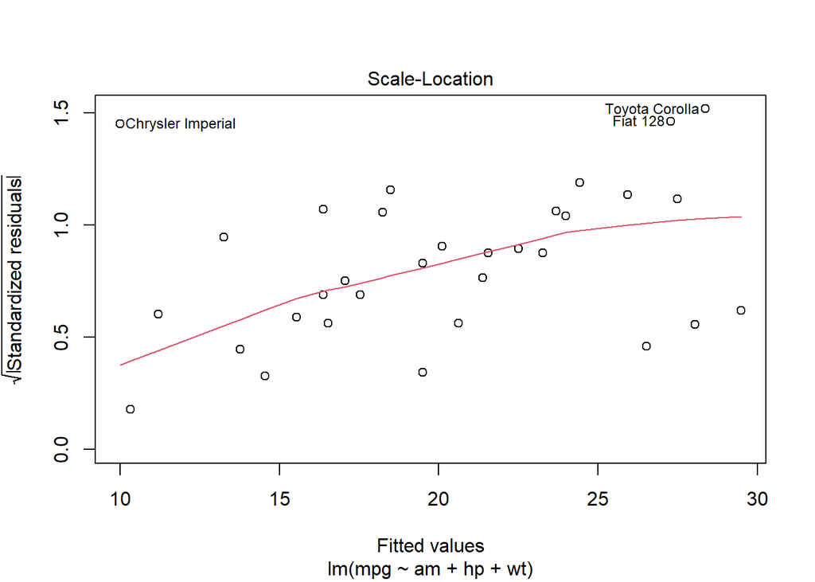

```r
plot(fit3,which = 3)
```

### Residual vs Leverage

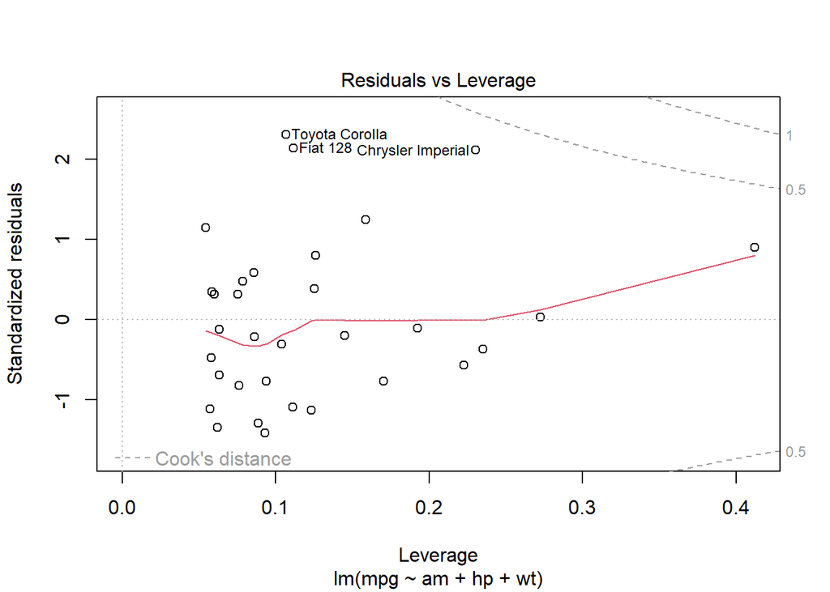

```r
plot(fit3,which = 5)
```

In the plot Residual vs Leverage, we identify any points with high influence on the regression model. As the points are inside the dotted lines (Cook’s distance), indicating **no points that disproportionate influence on the model.**